# Tugas 2 MPDW

Muhammad Nafiz

2023-09-08

```r
install.packages("forecast")
install.packages("TTR")
install.packages("TSA")
install.packages("orcutt")
install.packages("HoRM")
library(TTR)
library(forecast)
library(lmtest) #digunakan untuk uji formal pendeteksian autokorelasi
library(orcutt) #untuk membuat model regresi Cochrane-Orcutt
library(HoRM) #untuk membuat model regresi Hildreth-Lu
```

## input data mengenai total CO2 emissions di indonesia dari tahun 1889 sampai 2014 (ada 126 observasi)

```r
df <- read.csv("https://raw.githubusercontent.com/MNafiz/MPDW/main/Pertemuan%202/dataPertemuan2.csv")
df
```

```
##       X Year   Country  Total Solid.Fuel Liquid.Fuel Gas.Fuel Cement
## 1     0 1889 INDONESIA      1          1           0        0      0
## 2     1 1890 INDONESIA      4          4           0        0      0
## 3     2 1891 INDONESIA      6          6           0        0      0
## 4     3 1892 INDONESIA     49         51          -3        0      0
## 5     4 1893 INDONESIA    110         49          62        0      0
## 6     5 1894 INDONESIA    131         70          61        0      0
## 7     6 1895 INDONESIA    210         93         116        0      0
## 8     7 1896 INDONESIA    235        103         132        0      0
## 9     8 1897 INDONESIA    302        118         184        0      0
## 10    9 1898 INDONESIA    352        119         233        0      0
## 11   10 1899 INDONESIA    307        135         172        0      0
## 12   11 1900 INDONESIA    330        147         183        0      0
## 13   12 1901 INDONESIA    612        148         464        0      0
## 14   13 1902 INDONESIA    420        139         281        0      0
```

[output cut: 239 more lines]

## plot time series data dari tahun 1889 sampai 2014 mengenai CO2 emissions dan didapatkan polanya tidak beraturan yaitu stasioner lalu kemudian ada pola tren naik

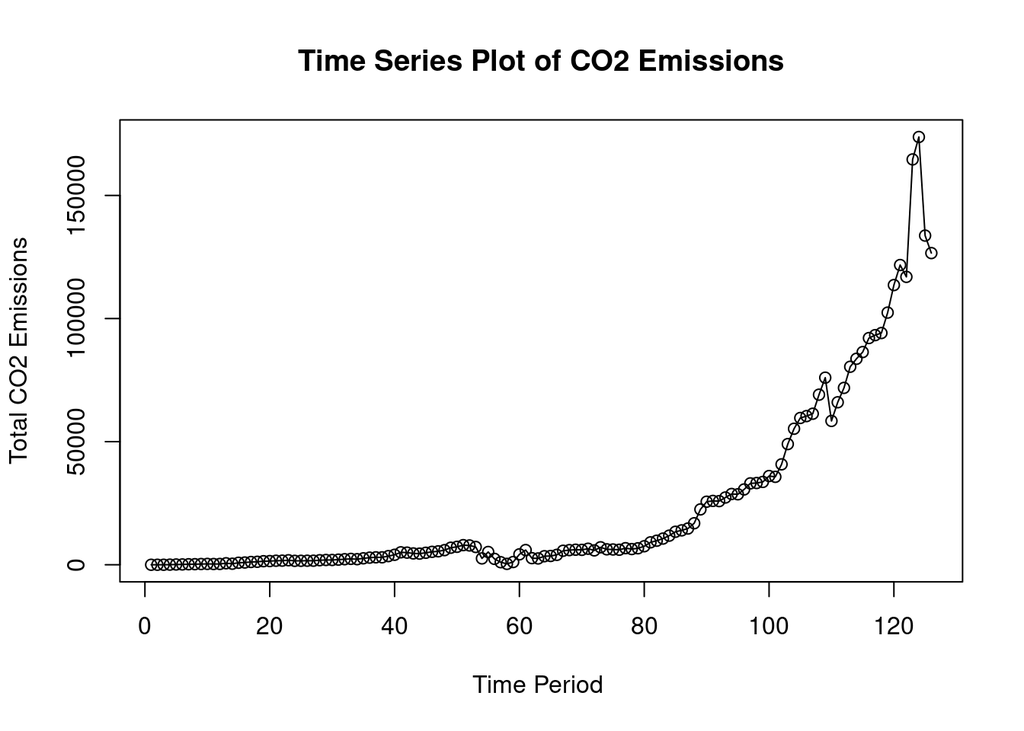

```r
data.ts <- ts(df$Total)

ts.plot(data.ts, xlab="Time Period ", ylab="Total CO2 Emissions", main= "Time Series Plot of CO2 Emissions")
points(data.ts)
```

## Melakukan splitting data latih dan uji

```r
n = length(data.ts)
propTrain = 0.7
trainNum = 96
training <- df[1:trainNum,]
testing <- df[(trainNum+1):n,]
training_ts <- ts(training$Total)
testing_ts <- ts(testing$Total)
```

## fungsi kalkulasi nilai SSE, MSE, dan MAPE

```r
akurasiFunc <- function(actual, predictions){
  error <- actual - predictions
  SSE <- sum(error^2)
  MSE <- mean(error^2)
  MAPE <- mean(abs(error)*100/actual)

  akurasi <- matrix(c(SSE, MSE, MAPE))
  row.names(akurasi) <- c("SSE", "MSE", "MAPE")
  colnames(akurasi) <- c("Akurasi")
  return(akurasi)
}
```

## Menggunakan Double Moving Average karena ada trend naik

```r
data.sma <- SMA(training_ts,n=4)
dma <- SMA(data.sma, n = 4)
At <- 2*data.sma - dma
Bt <- 2/(4-1)*(data.sma - dma)
data.dma<- At+Bt
data.ramal2<- c(NA, data.dma)

num <- n-trainNum
t = 1:(num)
f = c()

for (i in t) {
  f[i] = At[length(At)] + Bt[length(Bt)]*(i)
}

data.gab2 <- cbind(aktual = c(training_ts,rep(NA,num)), pemulusan1 = c(data.sma,rep(NA,num)),pemulusan2 = c(data.dma, rep(NA,num)),At = c(At, rep(NA,num)), Bt = c(Bt,rep(NA,num)),ramalan = c(data.ramal2, f[-1]))
data.gab2
```

```
##        aktual pemulusan1 pemulusan2         At           Bt    ramalan
##   [1,]      1         NA         NA         NA           NA         NA
##   [2,]      4         NA         NA         NA           NA         NA
##   [3,]      6         NA         NA         NA           NA         NA
##   [4,]     49      15.00         NA         NA           NA         NA
##   [5,]    110      42.25         NA         NA           NA         NA
##   [6,]    131      74.00         NA         NA           NA         NA
##   [7,]    210     125.00   226.5625   185.9375    40.625000         NA
##   [8,]    235     171.50   285.3542   239.8125    45.541667   226.5625
##   [9,]    302     219.50   339.5000   291.5000    48.000000   285.3542
##  [10,]    352     274.75   403.1875   351.8125    51.375000   339.5000
##  [11,]    307     299.00   395.3542   356.8125    38.541667   403.1875
##  [12,]    330     322.75   395.6667   366.5000    29.166667   395.3542
##  [13,]    612     400.25   527.0208   476.3125    50.708333   395.6667
##  [14,]    420     417.25   512.9792   474.6875    38.291667   527.0208
```

[output cut: 112 more lines]

## plot pada DMA menunjukkan bahwa DMA hanya bagus saat memprediksi data latih sedangkan buruk dalam memprediksi data uji dengan hasil prediksi yang masih jauh dengan nilai aktual

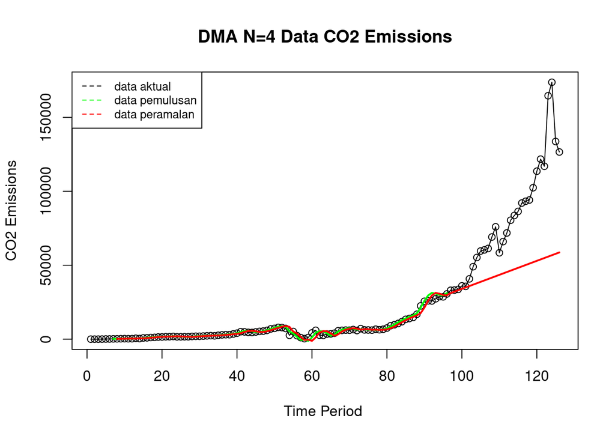

```r
data_ts = ts(df$Total)
ts.plot(data_ts, xlab="Time Period ", ylab="CO2 Emissions", main= "DMA N=4 Data CO2 Emissions")
points(data_ts)
lines(data.gab2[,3],col="green",lwd=2)
lines(data.gab2[,6],col="red",lwd=2)
legend("topleft",c("data aktual","data pemulusan","data peramalan"), lty=8, col=c("black","green","red"), cex=0.8)
```

## SSE, MSE. dan MAPE pada data latih dengan DMA

## didapatkan nilai MAPE sekitar 12 %

```r
akurasiFunc(data.gab2[,1][8:num],data.gab2[,6][8:num])
```

```
##           Akurasi
## SSE  558154.31250
## MSE   24267.57880
## MAPE     12.57514
```

## SSE, MSE. dan MAPE pada data uji dengan DMA

## nilai MAPE pada data UJI 36 %

```r
akurasiFunc(testing_ts[1:(num)], data.gab2[,6][(trainNum+1):n])
```

```
##           Akurasi
## SSE  6.507697e+10
## MSE  2.169232e+09
## MAPE 3.639153e+01
```

## Pemodelan Double Exponential Smoothing

## didapatkan nilai optimum dari beta sekitar 0,098 dan nilai optimum alpha adalah 1

```r
des.opt <- HoltWinters(training_ts, gamma = FALSE, beta = NULL, alpha = NULL)
print(paste(des.opt$beta,des.opt$alpha))
```

```
## [1] "0.0983632925144032 1"
```

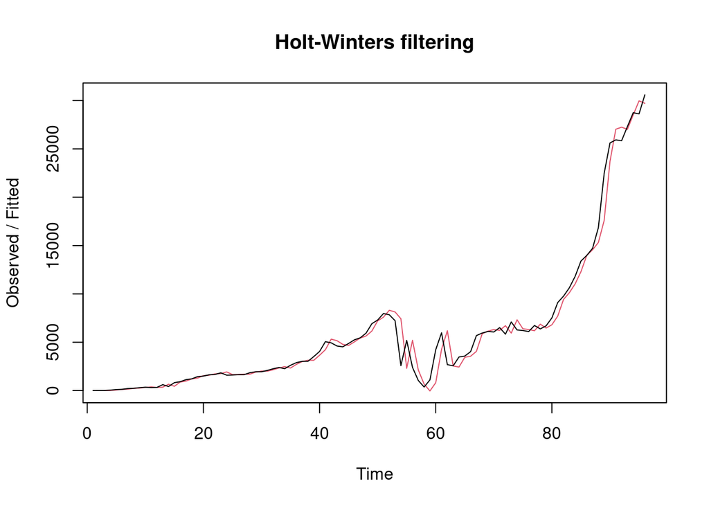

```r
plot(des.opt)
```

## Melakukan peramalan

```r
ramalan_des_opt <- forecast(des.opt,h = num)
des.opt$fitted[,1]
```

```
## Time Series:
## Start = 3
## End = 96
## Frequency = 1
##  [1]     7.000000     8.901637    55.845844   122.172625   144.040915
##  [6]   229.528867   255.067026   326.683508   379.173721   327.074476
## [11]   350.362241   658.097792   442.677709   878.694009   982.658639
## [16]  1205.954894  1293.844600  1538.712743  1588.806467  1728.251852
## [21]  1756.325281  1932.162349  1656.899587  1668.286389  1697.700773
## [26]  1696.615315  1911.309284  2016.918304  2007.942546  2153.423808
## [31]  2334.415176  2474.882683  2329.237931  2709.543156  2999.195122
## [36]  3136.635011  3131.047677  3657.011218  4226.470162  5320.458901
## [41]  5158.642258  4779.774362  4670.910644  5038.985545  5434.741621
## [46]  5646.127755  6157.132360  7207.875443  7595.543665  8306.376423
## [51]  8132.698829  7430.808037  2305.764950  5201.762896  2126.582093
## [56]   664.603937   -36.669366   815.825719  4273.556779  6190.211426
## [61]  2550.230563  2431.486606  3442.834930  3553.343305  4054.737010
## [66]  5879.488499  6150.719332  6311.402588  6230.772165  6710.533024
## [71]  5948.609439  7321.568916  6392.231498  6316.601698  6189.984585
## [76]  6869.397369  6468.258632  6808.856750  7704.102231  9424.997512
## [81] 10121.834729 11035.016265 12299.131486 13987.318175 14566.499972
## [86] 15318.205287 17609.467838 23712.549418 27035.779084 27244.306102
## [91] 27021.960837 28516.686770 29970.144411 29714.536488
```

## SSE, MSE. dan MAPE pada data latih dengan DES

## didapatkan nilai MAPE sebesar 18 % pada data latih

```r
akurasiFunc(training_ts[3:trainNum],des.opt$fitted[,1])
```

```
##           Akurasi
## SSE  1.215899e+08
## MSE  1.293510e+06
## MAPE 1.885134e+01
```

## didapatkan nilai MAPE sebesar 31 % pada data uji

```r
akurasiFunc(testing_ts[1:num],ramalan_des_opt$mean)
```

```
##           Akurasi
## SSE  5.395831e+10
## MSE  1.798610e+09
## MAPE 3.195246e+01
```

## Berdasarkan perbandingan akurasi data uji tersebut, terlihat nilai SSE, MSE, dan MAPE metode DES lebih kecil dibandingkan dengan metode DMA. Oleh karena itu, metode peramalan dan pemulusan yang terbaik antara keduanya adalah dengan metode DES.

## Setelah melakukan peramalan, data yang telah dimasukkan kemudian dieksplorasi. Eksplorasi pertama yang dilakukan adalah dengan menggunakan *scatter plot*.

## didapatkan pola hubungan yang membentuk persamaan y = akar dari x sehingga akan dilakukan transformasi supaya peubahnya lebih linier

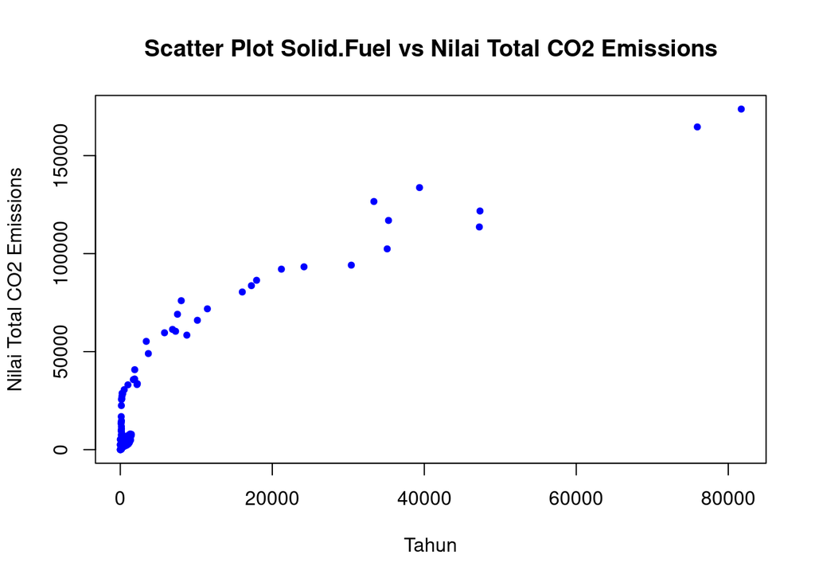

```r
#Eksplorasi Data
#Pembuatan Scatter Plot
plot(df$Solid.Fuel,df$Total, pch = 20, col = "blue",
     main = "Scatter Plot Solid.Fuel vs Nilai Total CO2 Emissions",
     xlab = "Tahun",
     ylab = "Nilai Total CO2 Emissions")
```

## plot yang dihasilkan menjadi lebih linier dan korelasi antar kedua peubah tersebut cukup besar dan positif yaitu sekitar 0,96

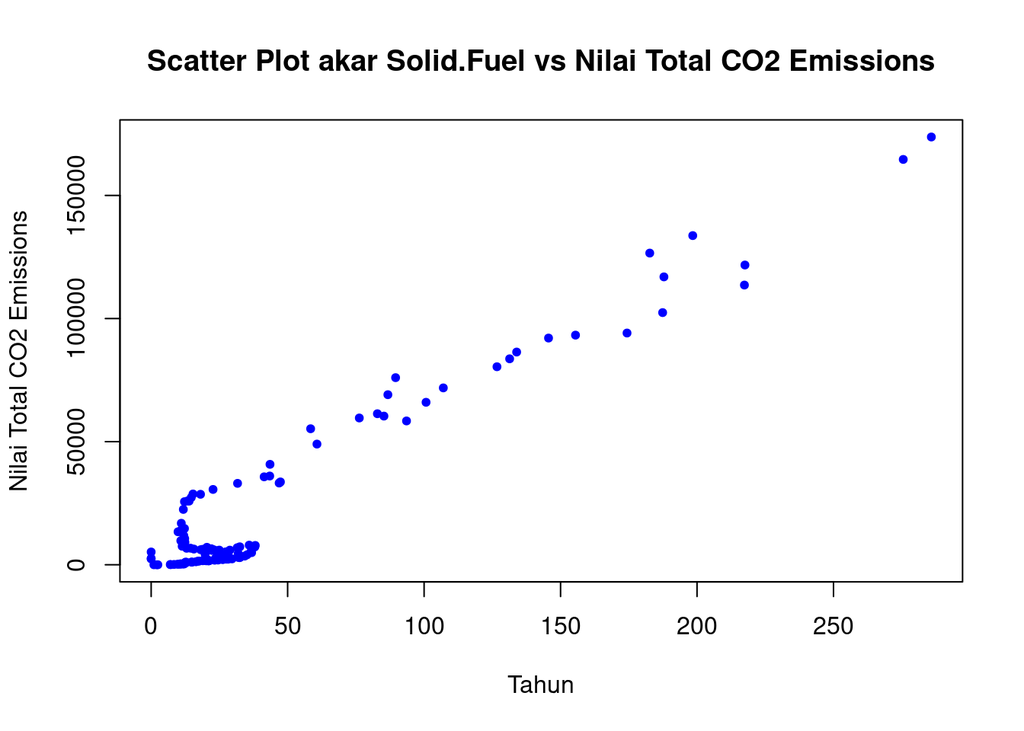

```r
#Eksplorasi Data
#Pembuatan Scatter Plot
plot(sqrt(df$Solid.Fuel),df$Total, pch = 20, col = "blue",
     main = "Scatter Plot akar Solid.Fuel vs Nilai Total CO2 Emissions",
     xlab = "Tahun",
     ylab = "Nilai Total CO2 Emissions")
```

```r
#Menampilkan Nilai Korelasi
cor(df$Total,sqrt(df$Solid.Fuel))
```

```
## [1] 0.9601061
```

Setalah mengetahui adanya hubungan antar dua peubah, maka model regresi dapat ditentukan.

```r
#Pembuatan Model Regresi
#model regresi linear berganda
model<- lm(df$Total~sqrt(df$Solid.Fuel)+df$Year+df$Liquid.Fuel)
summary(model)
```

```
##
## Call:
## lm(formula = df$Total ~ sqrt(df$Solid.Fuel) + df$Year + df$Liquid.Fuel)
##
## Residuals:
##     Min      1Q  Median      3Q     Max
## -9389.9 -2414.4  -131.9  2006.9 19197.1
##
## Coefficients:
##                       Estimate Std. Error t value Pr(>|t|)
## (Intercept)          1.559e+04  3.563e+04   0.437    0.663
## sqrt(df$Solid.Fuel)  2.783e+02  1.473e+01  18.888   <2e-16 ***
## df$Year             -1.084e+01  1.846e+01  -0.587    0.558
## df$Liquid.Fuel       1.360e+00  6.974e-02  19.503   <2e-16 ***
## ---
## Signif. codes:  0 '***' 0.001 '**' 0.01 '*' 0.05 '.' 0.1 ' ' 1
##
## Residual standard error: 3776 on 122 degrees of freedom
## Multiple R-squared:   0.99,  Adjusted R-squared:  0.9898
## F-statistic:  4040 on 3 and 122 DF,  p-value: < 2.2e-16
```

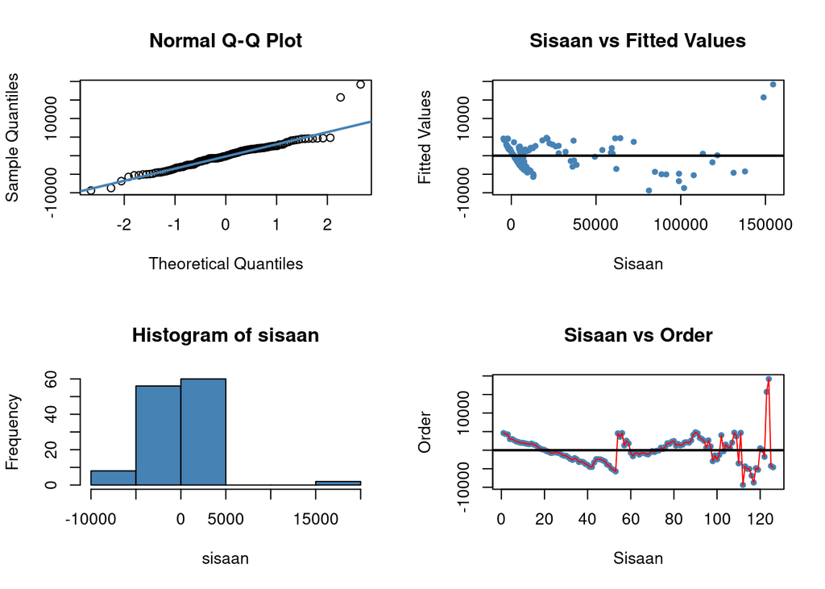

```r
#sisaan dan fitted value
sisaan<- residuals(model)
fitValue<- predict(model)

#Diagnostik dengan eksploratif
par(mfrow = c(2,2))
qqnorm(sisaan)
qqline(sisaan, col = "steelblue", lwd = 2)
plot(fitValue, sisaan, col = "steelblue", pch = 20, xlab = "Sisaan", ylab = "Fitted Values", main = "Sisaan vs Fitted Values")
abline(a = 0, b = 0, lwd = 2)
hist(sisaan, col = "steelblue")
plot(seq(1,length(sisaan),1), sisaan, col = "steelblue", pch = 20, xlab = "Sisaan", ylab = "Order", main = "Sisaan vs Order")
lines(seq(1,length(sisaan),1), sisaan, col = "red")
abline(a = 0, b = 0, lwd = 2)
```

## sisaan menyebar normal menurut kolmogorov-smirnov dengan alfa 5%

```r
#Melihat Sisaan Menyebar Normal/Tidak
#H0: sisaan mengikuti sebaran normal
#H1: sisaan tidak mengikuti sebaran normal
ks.test(sisaan, "pnorm", mean=mean(sisaan), sd=sd(sisaan))
```

```
##
##  Asymptotic one-sample Kolmogorov-Smirnov test
##
## data:  sisaan
## D = 0.087135, p-value = 0.2943
## alternative hypothesis: two-sided
```

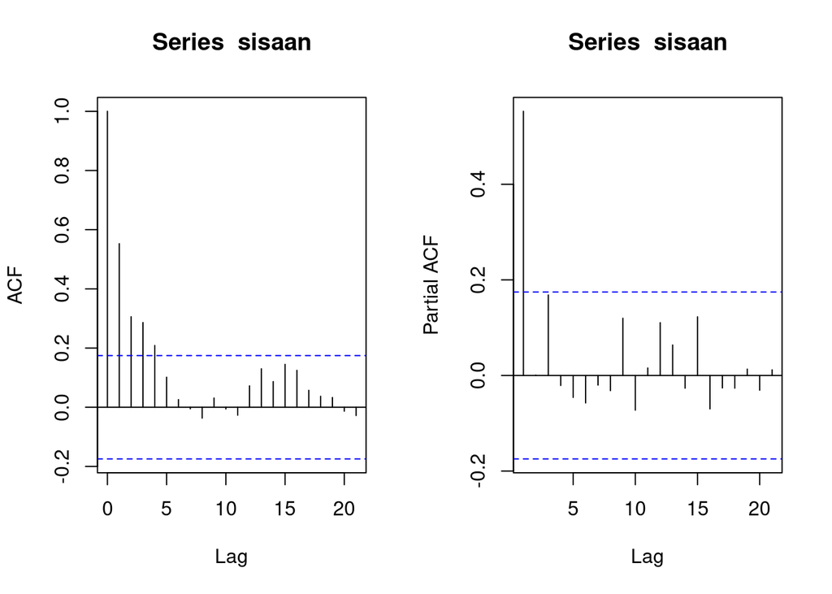

```r
#ACF dan PACF identifikasi autokorelasi
par(mfrow = c(1,2))
acf(sisaan)
pacf(sisaan)
```

## p-value durbin watson bernilai sangat kecil sehingga cukup bukti untuk mengatakan ada autokorelasi dalam sisaan

```r
#Deteksi autokorelasi dengan uji-Durbin Watson
#H0: tidak ada autokorelasi
#H1: ada autokorelasi
dwtest(model)
```

```
##
##  Durbin-Watson test
##
## data:  model
## DW = 0.87026, p-value = 1.447e-11
## alternative hypothesis: true autocorrelation is greater than 0
```

```r
#Penanganan Autokorelasi Hildreth lu
# Hildreth-Lu
hildreth.lu.func<- function(r, model){
  x <- model.matrix(model)[,-1]
  y <- model.response(model.frame(model))
  n <- length(y)
  t <- 2:n
  y <- y[t]-r*y[t-1]
  x <- x[t]-r*x[t-1]

  return(lm(y~x))
}
```

```r
#Pencariab rho yang meminimumkan SSE
r <- c(seq(0.1,0.9, by= 0.1))
tab <- data.frame("rho" = r, "SSE" = sapply(r, function(i){deviance(hildreth.lu.func(i, model))}))
round(tab, 4)
```

```
##   rho         SSE
## 1 0.1 11286274500
## 2 0.2  9204300387
## 3 0.3  7388841075
## 4 0.4  5837868413
## 5 0.5  4546970942
## 6 0.6  3506262626
## 7 0.7  2693340940
## 8 0.8  2061704191
## 9 0.9  1556057516
```

```r
tab
```

```
##   rho         SSE
## 1 0.1 11286274500
## 2 0.2  9204300387
## 3 0.3  7388841075
## 4 0.4  5837868413
## 5 0.5  4546970942
## 6 0.6  3506262626
## 7 0.7  2693340940
## 8 0.8  2061704191
## 9 0.9  1556057516
```

## didapatkan nilai rho optimum adalah 1,012

```r
#Rho optimal di 1.012
rOpt <- seq(1,1.1, by= 0.001)
tabOpt <- data.frame("rho" = rOpt, "SSE" = sapply(rOpt, function(i){deviance(hildreth.lu.func(i, model))}))
head(tabOpt[order(tabOpt$SSE),])
```

```
##      rho        SSE
## 13 1.012 1267662857
## 12 1.011 1267686967
## 14 1.013 1267696653
## 11 1.010 1267768800
## 15 1.014 1267788531
## 10 1.009 1267908165
```

```r
#Model terbaik
modelHL <- hildreth.lu.func(1.012, model)
summary(modelHL)
```

```
##
## Call:
## lm(formula = y ~ x)
##
## Residuals:
##      Min       1Q   Median       3Q      Max
## -20060.7   -748.5   -306.3    750.4  11019.3
##
## Coefficients:
##             Estimate Std. Error t value Pr(>|t|)
## (Intercept)   343.81     287.87   1.194    0.235
## x             419.04      21.82  19.206   <2e-16 ***
## ---
## Signif. codes:  0 '***' 0.001 '**' 0.01 '*' 0.05 '.' 0.1 ' ' 1
##
## Residual standard error: 3210 on 123 degrees of freedom
## Multiple R-squared:  0.7499, Adjusted R-squared:  0.7479
## F-statistic: 368.9 on 1 and 123 DF,  p-value: < 2.2e-16
```

```r
#Transformasi Balik
cat("y = ", coef(modelHL)[1]/(1-1.012), "+", coef(modelHL)[2],"x", sep = "")
```

```
## y = -28650.76+419.0398x
```

## didapatkan p-value durbin watson 26 % > 5 % sehingga tidak ada indikasi autokorelasi setelah di transformasi menggunakan hildreth-lu

```r
#Deteksi autokorelasi
dwtest(modelHL)
```

```
##
##  Durbin-Watson test
##
## data:  modelHL
## DW = 1.89, p-value = 0.268
## alternative hypothesis: true autocorrelation is greater than 0
```

## berdasarkan nilai MSE dan SSE, model hildreth-lu memiliki nilai MSE dan SSE yang lebih kecil dengan model regresi biasa ketika autokorelasi masih terjadi

```r
#Perbandingan
sseModelawal <- anova(model)$`Sum Sq`[-1]
sseModelHL <- anova(modelHL)$`Sum Sq`[-1]
mseModelawal <- sseModelawal/length(df$Total)
mseModelHL <- sseModelHL/length(df$Total)
akurasi <- matrix(c(sseModelawal,sseModelHL,
                    mseModelawal,mseModelHL),nrow=2,ncol=2,byrow = T)
colnames(akurasi) <- c("Model Awal", "Model Hildreth-Lu")
row.names(akurasi) <- c("SSE","MSE")
akurasi
```

```
##     Model Awal Model Hildreth-Lu
## SSE 6485590627        5422200516
## MSE 1739212583        1267662857
```